# Machine Learning Project

```r
# Suppress dplyr summarise grouping warning messages
options(dplyr.summarise.inform = FALSE)

library(tidyverse)
library(tidymodels)
library(discrim)
library(vip)
library(rpart.plot)
library(recipes)
library(parsnip)
credit_card_df <- readRDS(url('https://gmubusinessanalytics.netlify.app/data/credit_card_df.rds'))
```

# Data Analysis

In this section, you must think of at least 5 relevant questions that explore the relationship between `customer_status` and the other variables in the `credit_card_df` data set. The goal of your analysis should be discovering which variables drive the differences between customers who do and do not close their account.

# Question 1

**Question**:Is there a relationship between customer canceling their credit card and marital status?

**Answer**: Yes there is a relationship between the credit card canceling and marital status. At most half of the single people closed there account. 47% of the single closed there account, where as 43.6% of the married people closed there account. 44.9% of the divorced people closed account.

```r
credit_card_df %>%
  group_by(marital_status,customer_status) %>%
  summarise(count = n()) %>%
  mutate(perc = 100*count/sum(count))
```

| marital_status | customer_status | count | perc |
| --- | --- | --- | --- |
| single | closed_account | 944 | 47.03538 |
| single | active | 1063 | 52.96462 |
| married | closed_account | 989 | 43.64519 |
| married | active | 1277 | 56.35481 |
| divorced | closed_account | 159 | 44.91525 |
| divorced | active | 195 | 55.08475 |

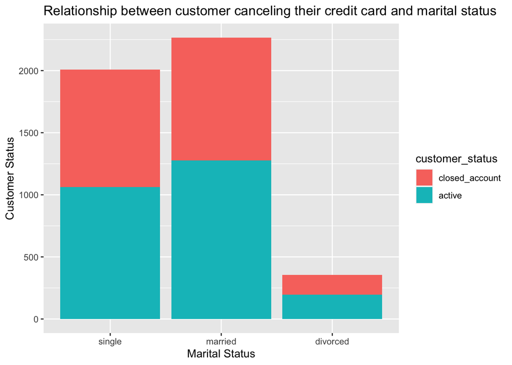

```r
ggplot(data = credit_card_df, aes(x = marital_status, fill = customer_status)) + geom_bar() +
   labs(title = "Relationship between customer canceling their credit card and marital status",
           x = "Marital Status", y = "Customer Status")
```

# Question 2

**Question**:Cancellation of credit card vs their annual income?

**Answer**: All most 2092 closed there credit account who’s average income of closed account people is 61601.51. Count of people who have there credit account active is 2535 and there average income is 62842.83.

```r
credit_card_df %>% group_by(customer_status) %>%
                  summarise(n_customers = n(),
                            min_income = min(income),
                            first_quartile = quantile(income, 0.25),
                            avg_income = mean(income),
                            third_quartile = quantile(income, 0.75),
                            max_income = max(income),
                            sd_income = sd(income))
```

| customer_status | n_customers | min_income | first_quartile | avg_income | third_quartile | max_income | sd_income |
| --- | --- | --- | --- | --- | --- | --- | --- |
| closed_account | 2092 | 30198 | 35311 | 61601.51 | 79796.0 | 168522 | 33659.36 |
| active | 2535 | 30094 | 35496 | 62842.83 | 79858.5 | 166225 | 33306.29 |

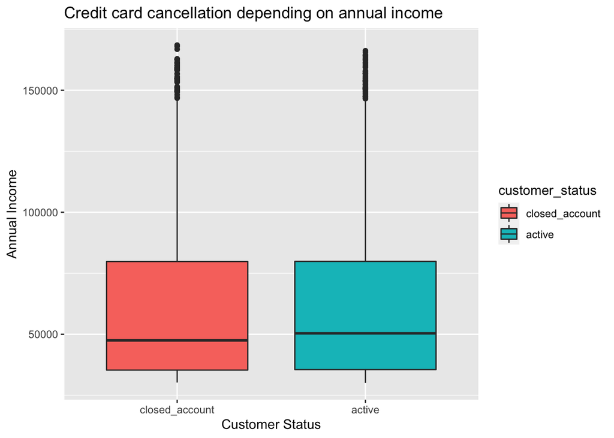

```r
ggplot(credit_card_df, aes(x=income,y = customer_status
,fill=customer_status)) + geom_boxplot() + coord_flip()+
  labs(title = "Credit card cancellation depending on annual income ",
           x = "Annual Income",
           y = "Customer Status")
```

# Question 3

**Question**:Does education level has an influence on cancellation of credit card?

**Answer**: When compared the relationship between the education level and cancellation of credit card we found nearly equal percent of people closed there account and active account. We also found that percentage of people who closed there account whose education level is doctorate is high of 7% which is 53.4% compared to active accounts of percentage 46.6%. In the remaining education levels the percentage of closed account is less than active accounts percentage.

```r
credit_card_df %>%
  group_by(education,customer_status) %>%
  summarise(count = n()) %>%
  mutate(perc = 100*count/sum(count))
```

| education | customer_status | count | perc |
| --- | --- | --- | --- |
| associates | closed_account | 874 | 45.35547 |
| associates | active | 1053 | 54.64453 |
| bachelors | closed_account | 201 | 42.85714 |
| bachelors | active | 268 | 57.14286 |
| masters | closed_account | 891 | 44.66165 |
| masters | active | 1104 | 55.33835 |
| doctorate | closed_account | 126 | 53.38983 |
| doctorate | active | 110 | 46.61017 |

# Question 4

**Question**:Transactions_last_year vs total_spend_last_year with customer_status. Is there a relationship?

```r
credit_card_df %>% group_by(customer_status) %>%
                  summarise(n_customers = n(),
                            min_charges = min(transactions_last_year),
                            first_quartile = quantile(transactions_last_year, 0.25),
                            avg_charges = mean(transactions_last_year),
                            third_quartile = quantile(transactions_last_year, 0.75),
                            max_charges = max(transactions_last_year),
                            sd_charges = sd(transactions_last_year),
                            pct_less_60 = mean(transactions_last_year <= 60))
```

| customer_status | n_customers | min_charges | first_quartile | avg_charges | third_quartile | max_charges | sd_charges | pct_less_60 |
| --- | --- | --- | --- | --- | --- | --- | --- | --- |
| closed_account | 2092 | 10 | 37 | 45.03776 | 51 | 94 | 14.59323 | 0.8513384 |
| active | 2535 | 11 | 54 | 68.45602 | 82 | 131 | 22.77175 | 0.3211045 |

```r
credit_card_df %>% group_by(customer_status) %>%
                  summarise(n_customers = n(),
                            min_charges = min(total_spend_last_year),
                            avg_charges = mean(total_spend_last_year),
                            max_charges = max(total_spend_last_year),
                            sd_charges = sd(total_spend_last_year))
```

| customer_status | n_customers | min_charges | avg_charges | max_charges | sd_charges |
| --- | --- | --- | --- | --- | --- |
| closed_account | 2092 | 510 | 3120.827 | 10583 | 2344.730 |
| active | 2535 | 893 | 4596.663 | 17498 | 3464.805 |

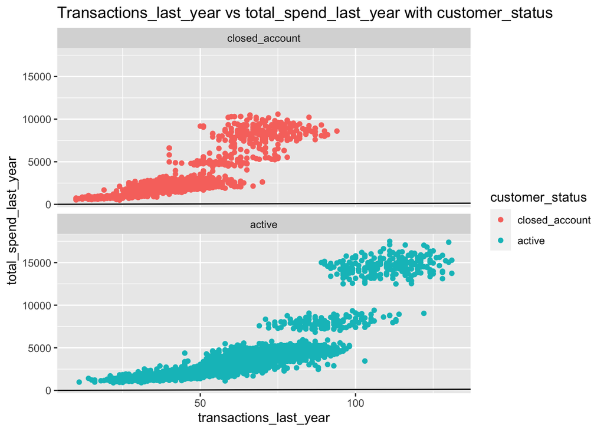

```r
ggplot(credit_card_df, aes(x= transactions_last_year , y= total_spend_last_year)) +geom_point(aes(colour= customer_status))+ facet_wrap(~customer_status,nrow=2)+geom_abline()+ggtitle("Transactions_last_year vs total_spend_last_year with customer_status")
```

# Question 5

**Question**:Most credit card cancellations are from which credit card type?

**Answer**: There is link between the card type and the cancellation of credit card service. Because we can see that 58.6% of blue card holder closed there account. Compared to the other card types silver and gold which has less percentage of credit card cancellation is less than active credit card service.

```r
c_type <- credit_card_df %>%
  group_by(card_type,customer_status) %>%
  summarise(count = n()) %>%
  mutate(perc = 100*count/sum(count))

c_type
```

| card_type | customer_status | count | perc |
| --- | --- | --- | --- |
| blue | closed_account | 1497 | 58.68287 |
| blue | active | 1054 | 41.31713 |
| silver | closed_account | 296 | 25.34247 |
| silver | active | 872 | 74.65753 |
| gold | closed_account | 299 | 32.92952 |
| gold | active | 609 | 67.07048 |

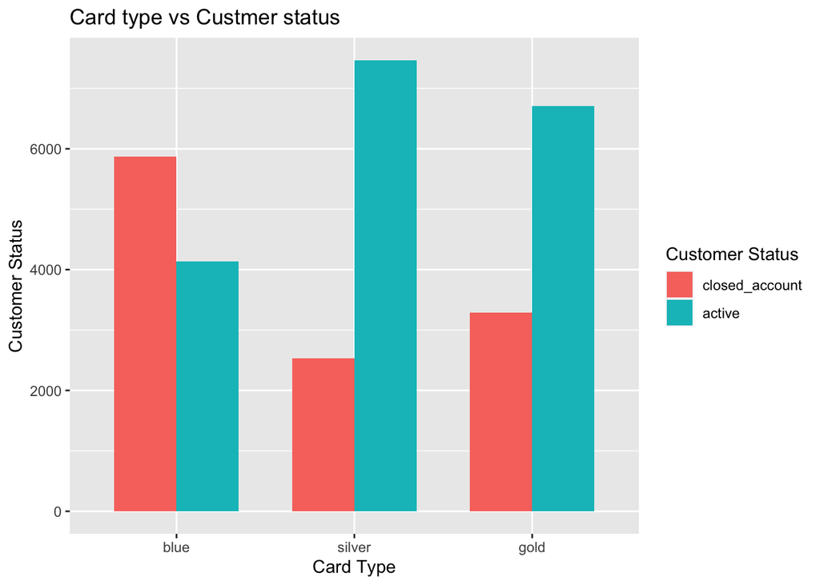

```r
#plot
ggplot(c_type, aes(x = factor(card_type), y = perc*100, fill = factor(customer_status))) +
  geom_bar(stat="identity", position = "dodge", width = 0.7) +
  labs(title = "Card type vs Custmer status",
       x = "Card Type", y = "Customer Status", fill = "Customer Status")
```

#Question 6:

**Question**: Are there any findings when compared with customer status, total accounts and months_inactive_last_year

**Answer**: From the graph we can say that people with 2 and 3 accounts has closed there credit card account. Also people who did not use there card for 3 months mostly closed there credit card account.

```r
credit_card_df %>% group_by(customer_status) %>%
                  summarise(n_customers = n(),
                            min_charges = min(total_accounts),
                            avg_charges = mean(total_accounts),
                            max_charges = max(total_accounts),
                            sd_charges = sd(total_accounts))
```

| customer_status | n_customers | min_charges | avg_charges | max_charges | sd_charges |
| --- | --- | --- | --- | --- | --- |
| closed_account | 2092 | 1 | 3.291587 | 6 | 1.583954 |
| active | 2535 | 1 | 3.936095 | 6 | 1.517544 |

```r
credit_card_df %>% group_by(customer_status) %>%
                  summarise(n_customers = n(),
                            min_charges = min(months_inactive_last_year),
                            avg_charges = mean(months_inactive_last_year),
                            max_charges = max(months_inactive_last_year),
                            sd_charges = sd(months_inactive_last_year))
```

| customer_status | n_customers | min_charges | avg_charges | max_charges | sd_charges |
| --- | --- | --- | --- | --- | --- |
| closed_account | 2092 | 0 | 2.691205 | 6 | 0.9044547 |
| active | 2535 | 0 | 2.261538 | 6 | 1.0089575 |

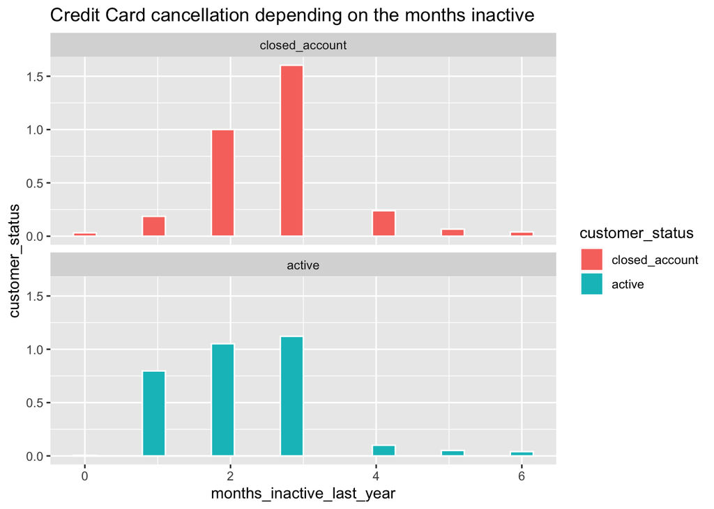

```r
ggplot(data = credit_card_df, aes(x = months_inactive_last_year, fill = customer_status)) +
   geom_histogram(aes(y = ..density..), color = "white", bins = 20) +
   facet_wrap(~ customer_status, nrow = 2) +
   labs(title = "Credit Card cancellation depending on the months inactive ",
           x = "months_inactive_last_year", y = "customer_status")
```

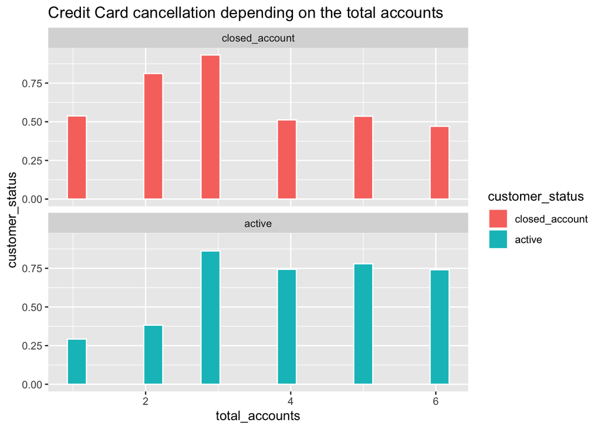

```r
ggplot(data = credit_card_df, aes(x = total_accounts, fill = customer_status)) +
   geom_histogram(aes(y = ..density..), color = "white", bins = 20) +
   facet_wrap(~ customer_status, nrow = 2) +
   labs(title = "Credit Card cancellation depending on the total accounts ",
           x = "total_accounts", y = "customer_status")
```

# Machine Learning

In this section of the project, you will fit **three classification algorithms** to predict the outcome variable,`customer_status`.

You must follow the machine learning steps below.

The data splitting and feature engineering steps should only be done once so that your models are using the same data and feature engineering steps for training.

- Split the `credit_card_df` data into a training and test set (remember to set your seed)
- Specify a feature engineering pipeline with the `recipes` package
  - You can include steps such as skewness transformation, correlation filters, dummy variable encoding or any other steps you find appropriate
- Specify a `parsnip` model object
  - You may choose from the following classification algorithms:
    - Logistic Regression
    - LDA
    - QDA
    - KNN
    - Decision Tree
    - Random Forest
- Package your recipe and model into a workflow
- Fit your workflow to the training data
  - If your model has hyperparameters:
    - Split the training data into 5 folds for 5-fold cross validation using `vfold_cv` (remember to set your seed)
    - Perform hyperparamter tuning with a random grid search using the `grid_random()` function
    - Refer to the following tutorial for an example - [Random Grid Search](https://gmubusinessanalytics.netlify.app/lesson-08-r-tutorial.html#Hyperparameter_Tuning14)
    - Hyperparameter tuning can take a significant amount of computing time. Be careful not to set the `size` argument of `grid_random()` too large. I recommend `size` = 10 or smaller.
    - Select the best model with `select_best()` and finalize your workflow
- Evaluate model performance on the test set by plotting an ROC curve using `autoplot()` and calculating the area under the ROC curve on your test data

```r
set.seed(56)

cc_split <- initial_split(credit_card_df , prop = 0.75,
                              strata = customer_status)

cc_training <- cc_split %>% training()

cc_test<- cc_split  %>% testing()

# Create cross validation folds for hyperparameter tuning
set.seed(56)

cc_folds<- vfold_cv(cc_training, v = 5)
```

# Feature Engineering

```r
cc_recipe<- recipe(customer_status ~., data = credit_card_df) %>%
                 step_YeoJohnson(all_numeric(), -all_outcomes()) %>%
                 step_normalize(all_numeric(), -all_outcomes()) %>%
                 step_dummy(all_nominal(), -all_outcomes())
```

#Model 1

# Logistic Regression

```r
logistic_model<- logistic_reg() %>%
                  set_engine('glm') %>%
                  set_mode('classification')
```

## Creating a Workflow

```r
logistic_wf<- workflow() %>%
               add_model(logistic_model) %>%
               add_recipe(cc_recipe)
```

## Fitting Model

```r
logistic_fit<-  logistic_wf%>%
                 last_fit(split = cc_split)
```

## Collecting Predictions

```r
logistic_results <-  logistic_fit%>%
                     collect_predictions()
logistic_results
```

| id | .pred_closed_account | .pred_active | .row | .pred_class | customer_status | .config |
| --- | --- | --- | --- | --- | --- | --- |
| train/test split | 3.450369e-01 | 6.549631e-01 | 3 | active | closed_account | Preprocessor1_Model1 |
| train/test split | 2.350118e-01 | 7.649882e-01 | 20 | active | active | Preprocessor1_Model1 |
| train/test split | 6.982217e-01 | 3.017783e-01 | 21 | closed_account | closed_account | Preprocessor1_Model1 |
| train/test split | 6.556262e-02 | 9.344374e-01 | 23 | active | active | Preprocessor1_Model1 |
| train/test split | 5.564445e-03 | 9.944356e-01 | 36 | active | active | Preprocessor1_Model1 |
| train/test split | 6.310508e-01 | 3.689492e-01 | 38 | closed_account | closed_account | Preprocessor1_Model1 |
| train/test split | 8.600884e-01 | 1.399116e-01 | 39 | closed_account | closed_account | Preprocessor1_Model1 |
| train/test split | 3.898251e-01 | 6.101749e-01 | 41 | active | active | Preprocessor1_Model1 |
| train/test split | 7.945724e-01 | 2.054276e-01 | 44 | closed_account | closed_account | Preprocessor1_Model1 |
| train/test split | 9.746486e-01 | 2.535144e-02 | 48 | closed_account | closed_account | Preprocessor1_Model1 |

[output cut: 1147 more lines]

## ROC Curve

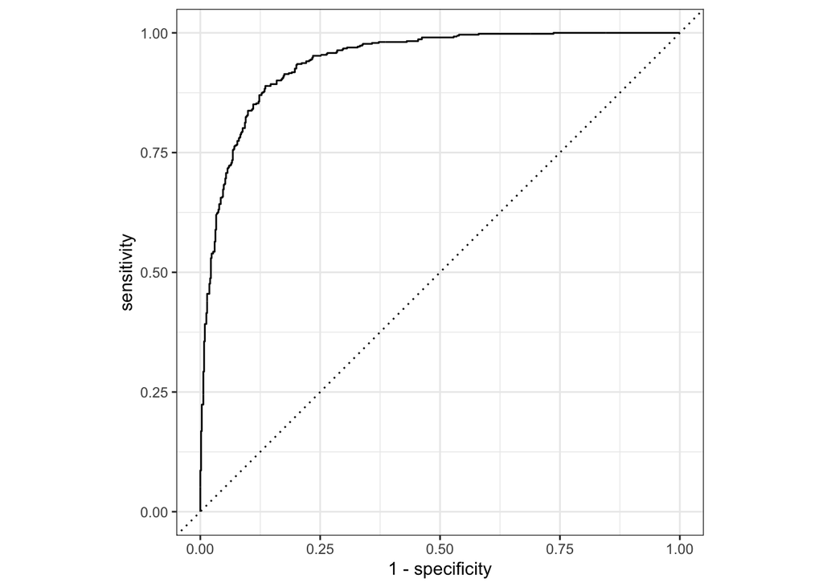

```r
## ROC Curve
roc_curve(logistic_results , truth = customer_status , estimate = .pred_closed_account ) %>%
  autoplot()
```

```r
# ROC AUC
roc_auc(logistic_results, truth = customer_status, .pred_closed_account)
```

| .metric | .estimator | .estimate |
| --- | --- | --- |
| roc_auc | binary | 0.9418032 |

```r
# Confusion Matrix
conf_mat(logistic_results, truth = customer_status, estimate = .pred_class)
```

```
##                 Truth
## Prediction       closed_account active
##   closed_account            455     78
##   active                     68    556
```

# Model 2

#KNN

```r
library(kknn)
set.seed(310)
knn_model <- nearest_neighbor(neighbors =tune()) %>%
             set_engine('kknn') %>%
             set_mode('classification')
```

##Creating Workflow

```r
knn_wf <- workflow() %>%
          add_model(knn_model) %>%
          add_recipe(cc_recipe)


k_grid <- tibble(neighbors = c(10, 15, 25, 45, 60, 80, 100, 120, 140, 180))


set.seed(310)

knn_tuning <- knn_wf %>%
              tune_grid(resamples = cc_folds, grid = k_grid)

best_k <- knn_tuning %>%
          select_best(metric = 'roc_auc')

final_knn_wf <- knn_wf %>%
                finalize_workflow(best_k)
```

## Fitting Model

```r
knn_fit <- final_knn_wf %>%
           last_fit(split = cc_split)
```

## Collecting Predictions

```r
knn_results <-   knn_fit %>%
                 collect_predictions()
```

## ROC Curve

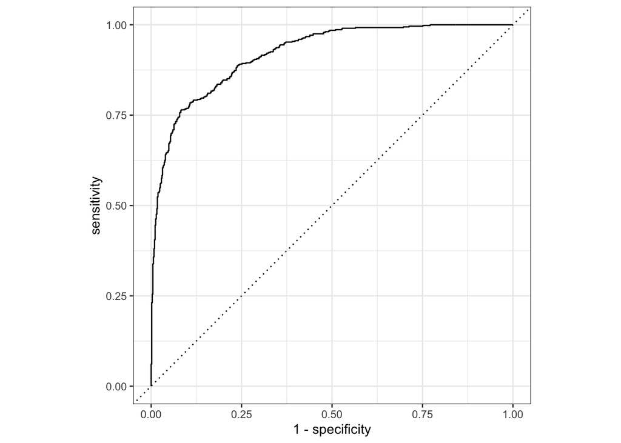

```r
roc_curve( knn_results , truth = customer_status , estimate = .pred_closed_account ) %>%
  autoplot()
```

```r
roc_auc(knn_results, truth = customer_status, .pred_closed_account )
```

| .metric | .estimator | .estimate |
| --- | --- | --- |
| roc_auc | binary | 0.9202068 |

```r
conf_mat(knn_results, truth = customer_status, estimate = .pred_class)
```

```
##                 Truth
## Prediction       closed_account active
##   closed_account            419     95
##   active                    104    539
```

```r
my_metrics<- metric_set(accuracy,f_meas)
my_metrics(knn_results,truth=customer_status,estimate=.pred_class)
```

| .metric | .estimator | .estimate |
| --- | --- | --- |
| accuracy | binary | 0.8280035 |
| f_meas | binary | 0.8081003 |

# Model 3

#Decision Trees

#Model Specification

```r
tree_model <- decision_tree(cost_complexity = tune(),
                            tree_depth = tune(),
                            min_n = tune()) %>%
              set_engine('rpart') %>%
              set_mode('classification')
```

# Creating the Workflow

```r
tree_flow <- workflow() %>%
                 add_model(tree_model) %>%
                 add_recipe(cc_recipe)
```

#Hyperparamter tuning

```r
## Create a grid of hyper parameter values to test
t_grid <- grid_regular(cost_complexity(),
                          tree_depth(),
                          min_n(),
                          levels = 2)

t_grid
```

| cost_complexity | tree_depth | min_n |
| --- | --- | --- |
| 1e-10 | 1 | 2 |
| 1e-01 | 1 | 2 |
| 1e-10 | 15 | 2 |
| 1e-01 | 15 | 2 |
| 1e-10 | 1 | 40 |
| 1e-01 | 1 | 40 |
| 1e-10 | 15 | 40 |
| 1e-01 | 15 | 40 |

#Tuning hyperparameters

```r
## Tune decision tree work flow
set.seed(65)

t_tune <- tree_flow %>%
               tune_grid(resamples = cc_folds,
                         grid = t_grid)
```

## Show the top 5 best models based on roc_auc metric

```r
t_tune %>% show_best('roc_auc')
```

| cost_complexity | tree_depth | min_n | .metric | .estimator | mean | n | std_err | .config |
| --- | --- | --- | --- | --- | --- | --- | --- | --- |
| 1e-10 | 15 | 40 | roc_auc | binary | 0.9502096 | 5 | 0.005600466 | Preprocessor1_Model7 |
| 1e-10 | 15 | 2 | roc_auc | binary | 0.9109364 | 5 | 0.004790632 | Preprocessor1_Model3 |
| 1e-10 | 1 | 2 | roc_auc | binary | 0.7636351 | 5 | 0.007256002 | Preprocessor1_Model1 |
| 1e-01 | 1 | 2 | roc_auc | binary | 0.7636351 | 5 | 0.007256002 | Preprocessor1_Model2 |
| 1e-01 | 15 | 2 | roc_auc | binary | 0.7636351 | 5 | 0.007256002 | Preprocessor1_Model4 |

```r
## Select best model based on roc_auc
best_tree <- t_tune %>%
             select_best(metric = 'roc_auc')

# View the best tree parameters
best_tree
```

| cost_complexity | tree_depth | min_n | .config |
| --- | --- | --- | --- |
| 1e-10 | 15 | 40 | Preprocessor1_Model7 |

```r
final_tree_flow <- tree_flow %>%
                       finalize_workflow(best_tree)
```

#Fittiing the Model

```r
tree_wf_fit <- final_tree_flow %>%
               fit(data = cc_training)
```

```r
tree_fit <- tree_wf_fit %>%
            extract_fit_parsnip()
```

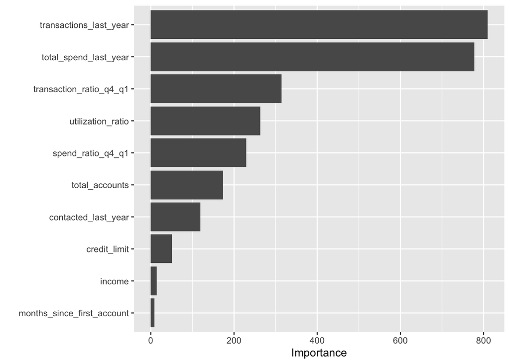

```r
vip(tree_fit)
```

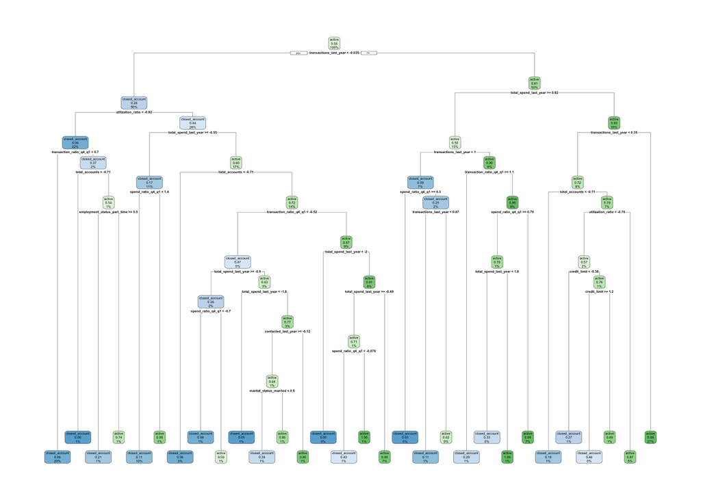

```r
rpart.plot(tree_fit$fit, roundint = FALSE)
```

#Train and Evaluate With last_fit()

```r
tree_last_fit <- final_tree_flow %>%
                 last_fit(cc_split)
```

```r
tree_last_fit %>% collect_metrics()
```

| .metric | .estimator | .estimate | .config |
| --- | --- | --- | --- |
| accuracy | binary | 0.8997407 | Preprocessor1_Model1 |
| roc_auc | binary | 0.9447723 | Preprocessor1_Model1 |

```r
t_pred <- tree_last_fit %>% collect_predictions()
```

## ROC Curve and Confusion Matrix

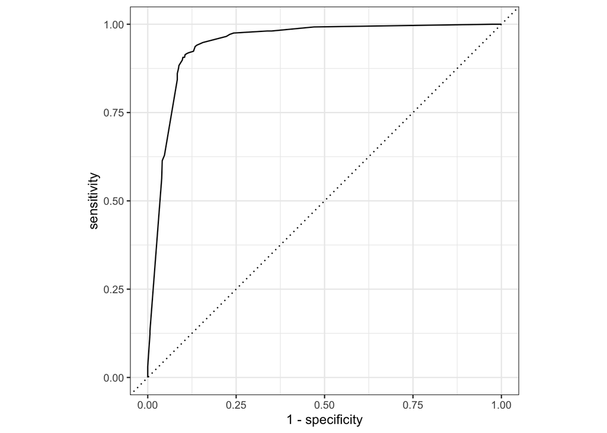

```r
#ROC Curve
roc_curve(t_pred, truth  = customer_status, estimate = .pred_closed_account) %>%
            autoplot()
```

```r
#roc-AUC
roc_auc(t_pred, truth = customer_status, .pred_closed_account)
```

| .metric | .estimator | .estimate |
| --- | --- | --- |
| roc_auc | binary | 0.9447723 |

```r
#Confusion Matrix

conf_mat(t_pred, truth = customer_status, estimate = .pred_class)
```

```
##                 Truth
## Prediction       closed_account active
##   closed_account            481     74
##   active                     42    560
```

# Summary of Results

Write a summary of your overall findings and recommendations to the executives at the bank. Think of this section as your closing remarks of a presentation, where you summarize your key findings, model performance, and make recommendations to improve customer retention and service at the bank.

Your executive summary must be written in a [professional tone](https://www.universalclass.com/articles/writing/business-writing/appropriate-tone-in-business-communications.htm), with minimal grammatical errors, and should include the following sections:

1. An introduction where you explain the business problem and goals of your data analysis
   - What problem(s) is this company trying to solve? Why are they important to their future success?
   - What was the goal of your analysis? What questions were you trying to answer and why do they matter?
2. Highlights and key findings from your Exploratory Data Analysis section
   - What were the interesting findings from your analysis and **why are they important for the business**?
   - This section is meant to **establish the need for your recommendations** in the following section
3. Your “best” classification model and an analysis of its performance
   - In this section you should talk about the expected error of your model on future data
     - To estimate future performance, you can use your model performance results on the **test data**
   - You should discuss at least one performance metric, such as an F1, sensitivity, specificity, or ROC AUC for your model. However, you must explain the results in an **intuitive, non-technical manner**. Your audience in this case are executives at a bank with limited knowledge of machine learning.
4. Your recommendations to the bank on how to reduce the number of customers closing their credit card accounts
   - Each recommendation must be supported by your data analysis results
   - You must clearly explain why you are making each recommendation and which results from your data analysis support this recommendation
   - You must also describe the potential business impact of your recommendation:
     - Why is this a good recommendation?
     - What benefits will the business achieve?

**Summary**

Add your summary here. Please do not place your text within R code chunks.

• The US Bank has experienced record levels of customers closing their credit card service in the past couple of months and this is leading to large financial losses. The bank is looking to find out the factors that lead to customers canceling their credit card account and whether it can predict if a customer will cancel their account in the future. It is important to find the problem of why customers are canceling their credit card services. • The goal of my analysis is to identify the reason behind why customers are canceling their credit card account and try to minimize the risk of canceling the credit card.

Many elements such as customer age, education level, marital status, employment_status, income, and card_type are taken into considerations to predict the reason behind why the customer is canceling their credit card.

-Is there a link between a customer’s decision to cancel their credit card and their marital status? -Credit card cancellation versus yearly income? -Is there a link between education and credit card cancellation? -With customer status, compare transactions to total spend last year. Is there a connection? -Which credit card type accounts for the majority of credit card cancellations? -When comparing customer status, total accounts, and months inactive last year, are there any conclusions?

The model limitations: • The models always perform better when the data set is larger. Since the dataset taken has lesser data, the performance is higher. • Also, the factors for the model are limited to the target variable that might get affected if more factor variables are added.

• From all the observations, it is important for the business to maintain customers be in their service. We need to decrease monthly credit charges and if possible increase the credit card limit. Implement some offers for every 1 year and 2-year so that customers can stay for a long time and give offers on all the credit card services equally. Bank can decrease the interest rate to attract the customer. Also, we can give offers such as when we refer a friend and he applies for a credit card from that bank we can give rewards to both the customers. We can also increase the rate of cash back for online shopping and also we can give points on credit cards depending on their travel rate where the count of miles is considered. This way we can increase the number of customers to incerase the bank profits.